# R Notebook

# Lab1

```r
#library(tidyverse)
library(readr)
library(dplyr)
library(ggplot2)

series_from_imdb <- read_csv("~/Documents/ad1/lab1-parte1/series_from_imdb.csv")
#series_from_imdb <- read_csv("~/Documentos/ad1/lab1-parte1/series_from_imdb.csv")


minhas_series <- series_from_imdb %>% filter(series_name %in% c("Breaking Bad",
                                                                "House of Cards",
                                                                "Game of Thrones",
                                                                "Narcos"))
```

```r
summary(minhas_series)
```

```
 series_name          series_ep         season        season_ep          url
 Length:194         Min.   : 1.00   Min.   :1.000   Min.   : 1.000   Length:194
 Class :character   1st Qu.:13.00   1st Qu.:2.000   1st Qu.: 3.000   Class :character
 Mode  :character   Median :26.00   Median :3.000   Median : 6.000   Mode  :character
                    Mean   :27.69   Mean   :2.959   Mean   : 6.397
                    3rd Qu.:42.00   3rd Qu.:4.000   3rd Qu.: 9.000
                    Max.   :62.00   Max.   :6.000   Max.   :16.000
   Episode            UserRating      UserVotes            r1               r10
 Length:194         Min.   : 7.70   Min.   :  1755   Min.   :0.00438   Min.   :0.1642
 Class :character   1st Qu.: 8.60   1st Qu.:  3034   1st Qu.:0.01563   1st Qu.:0.2992
 Mode  :character   Median : 8.80   Median :  9088   Median :0.02720   Median :0.4166
                    Mean   : 8.91   Mean   : 11828   Mean   :0.03020   Mean   :0.4484
                    3rd Qu.: 9.20   3rd Qu.: 13781   3rd Qu.:0.04125   3rd Qu.:0.5529
                    Max.   :10.00   Max.   :137670   Max.   :0.11628   Max.   :0.9288
       r2                 r3                  r4                 r5                 r6
 Min.   :0.000000   Min.   :0.0003253   Min.   :0.000000   Min.   :0.000987   Min.   :0.001442
 1st Qu.:0.001430   1st Qu.:0.0015696   1st Qu.:0.001565   1st Qu.:0.004304   1st Qu.:0.008444
 Median :0.002136   Median :0.0021837   Median :0.002611   Median :0.006884   Median :0.016519
 Mean   :0.002479   Mean   :0.0025611   Mean   :0.003201   Mean   :0.007752   Mean   :0.017692
 3rd Qu.:0.002878   3rd Qu.:0.0027625   3rd Qu.:0.004118   3rd Qu.:0.009545   3rd Qu.:0.023831
 Max.   :0.018607   Max.   :0.0214172   Max.   :0.021949   Max.   :0.044050   Max.   :0.089868
       r7                 r8                 r9
 Min.   :0.003023   Min.   :0.008516   Min.   :0.02401
 1st Qu.:0.029254   1st Qu.:0.104369   1st Qu.:0.18891
 Median :0.059906   Median :0.194092   Median :0.23977
 Mean   :0.062353   Mean   :0.184128   Mean   :0.24119
 3rd Qu.:0.088830   3rd Qu.:0.256295   3rd Qu.:0.29164
 Max.   :0.223495   Max.   :0.411814   Max.   :0.39045
```

Nenhuma das series escolhidas veio com algum valor inesperado. As notas que os usuarios atribuiram as series variam de 7.7 a 10, e nao possuem valores faltando.

### Boxplot

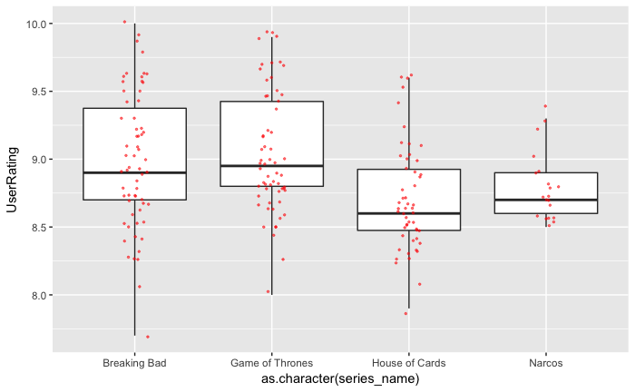

```r
minhas_series %>%
    ggplot(aes(x = as.character(series_name), y = UserRating)) +
    geom_boxplot(outlier.color = NA) +
    geom_jitter(width = .1, size = .5, alpha = .5, color = "red")
```

#### Qual das séries que você escolheu é mais bem avaliada no IMDB? A diferença é grande? Pequena?

Considerando a mediana como meio de mensurar a qualidade das series, a serie mais bem avaliada é Game of Thrones.

A mediana foi escolhida como forma de resumo dos dados pois é mais robusta a outliers que a média.

Em conjunto com a meiana, a serie Game of thrones possui o valor do primeiro quartil maior que o dos boxplots dos outros seriados. A maior parte das avaliacoes da serie game of thrones estao acima de 8.79, o que nao é verdade para os outros seriados, apesar de que breaking bad tem compartamento bem proximo.

Game of Thrones e Breaking Bad parecem ter uma qualidade de episodios parecida, pois as notas atribuidas pelos usuarios tem distribuiçao similar.

A diferença nao é grande. Visto que os episodios podem receber notas entre 1 e 10, a mediana das notas de todas as series escolhidas estão entre 8 e 9.

#### Qual das séries que você escolheu tem episódios de qualidade mais irregular segundo o IMDB? A diferença é grande? Pequena?

Qualidade irregular é indicada pela variancia das notas atribuidas as series pelos usuarios.

A serie que mais varia de qualidade entre um valor maximo e um valor minimo é Breaking Bad. De acordo com o plot acima, a variaçao entre Breaking Bad, Game of Thrones e House of Cards tem variancia similar. Narcos parece ter seriados com qualidade mais constante, a maior parte das avaliaçoes estao concentradas proximo a mediana.

**Desvio padrão:**

```r
got <- minhas_series %>%
  filter(series_name == "Game of Thrones")
bb <- minhas_series %>%
  filter(series_name == "Breaking Bad")
hoc <- minhas_series %>%
  filter(series_name == "House of Cards")
narcos <- minhas_series %>%
  filter(series_name == "Narcos")
```

```r
sd(got$UserRating)
```

```
[1] 0.4492807
```

```r
sd(bb$UserRating)
```

```
[1] 0.498472
```

```r
sd(hoc$UserRating)
```

```
[1] 0.3907828
```

```r
sd(narcos$UserRating)
```

```
[1] 0.253398
```

```r
#Game of Thrones: 0.4492807
#Breaking Bad:    0.498472
#House of Cards:  0.3907828
#Narcos:          0.253398
```

O desvio padrao mostra como as avaliacoes variam de acordo com a mediana, as series com qualidade mais irregular tem um maior desvio padrao.

Narcos possui o menor desvio padrao, a maior concentracao de pontos esta em torno da mediana como pode se observar no boxplot.